# My Simple Logistic Regression

### Background

An example data set that we often use in lessons on machine learning is Edgar Anderson’s Iris Data Set, which gives the measurements in centimeters of the variables sepal length and width and petal length and width, respectively, for 50 flowers from each of 3 species of iris. The species are Iris setosa, versicolor, and virginica. I have found it fascinating how strong the correlation is between the dimensions of the flower and type of flower and that this sort of correlation would occur so strongly in nature. While there may be other key giveaways of the type of flower for a flower expert, it would be interesting to see if using just one measurement on the flower will indicate to us the type of flower. With this example our question will be if there is a clear difference between the sepal width of setosas and other types of iris.

### Analysis

The probability of a flower being a setosa based on the measured sepal width is given by the following logistic regression model.

$$P(Y_i = 1|\, x_i) = \frac{e^{\beta_0 + \beta_1 x_i}}{1+e^{\beta_0 +
\beta_1 x_i}} = \pi_i$$

In this model, for each measurement i:

$$\text {- } Y_i = \text{ 1 denotes that the flower is a setosa}$$

$$\text {- } Y_i = \text{ 0 denotes that the flower is not a setosa}$$

$$\text {- } x_i \text{ denotes the length of the sepal width}$$

### Hypothesis

$$H_0: \beta_1 = 0$$

$$H_a: \beta_1 \ne 0$$

### Test

```r
iris.glm <- glm( Species == 'setosa' ~ Sepal.Width, data=iris, family=binomial)
summary(iris.glm) %>% pander::pander()
```

|  | Estimate | Std. Error | z value | Pr(>\|z\|) |
| --- | --- | --- | --- | --- |
| **(Intercept)** | -15.72 | 2.622 | -5.996 | 2.027e-09 |
| **Sepal.Width** | 4.79 | 0.8246 | 5.809 | 6.294e-09 |

(Dispersion parameter for binomial family taken to be 1 )

| Null deviance: | 191.0 on 149 degrees of freedom |
| --- | --- |
| Residual deviance: | 123.8 on 148 degrees of freedom |

The test gives us the equation

$$P(Y_i = 1|\, x_i) = \frac{e^{ -15.72 + 4.79 x_i}}{1+e^{-15.72 + 4.79
x_i}} = \pi_i$$

Important to note it that the p-value for the test of sepal width shows a significant result (p=6.294e-09), giving sufficient evidence to conclude that β1≠0.

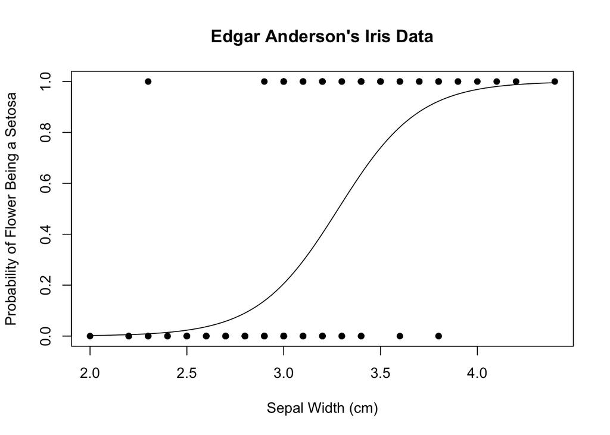

```r
plot( Species == 'setosa' ~ Sepal.Width, data=iris, xlab="Sepal Width (cm)", ylab='Probability of Flower Being a Setosa', pch=16, main="Edgar Anderson's Iris Data")

#Getting the coeffiencts
b <- coef(iris.glm)
curve(exp(b[1]+b[2]*x)/(1+exp(b[1]+b[2]*x)), add=TRUE)
```

This plot allows us to visualize our logistical regression test. The points represent actual observations and data that was collected from the flowers. The curve tells us the theoretical likelihood of an iris flower being a setosa at a given sepal width. An example would be that if we were to find a flower with a sepal width of 3.5 cm we would have a little less than an 80% likelihood of the flower being a setosa.

### Checking Model Assumptions

Because not all xi values are replicated many times, we must use the Hosmer-Lemeshow Test.

```r
hoslem.test(iris.glm$y, iris.glm$fitted, g=10) %>% pander::pander()
```

Hosmer and Lemeshow goodness of fit (GOF) test: `iris.glm$y, iris.glm$fitted`

| Test statistic | df | P value |
| --- | --- | --- |
| 6.317 | 8 | 0.6117 |

We have a p-value of .6117 we will fail to reject the null that a logistic regression is a good fit for our data and say that the requirements for a logistic regression with this data are met.